# IE 425 ASSIGNMENT 1

Ramazan Eraslan

5/3/2021

# PART A

## Installing Required Libraries and Data

```r
library(caTools)
library(kernlab)
library(rpart)
library(rpart.plot)
library(tree)
data("spam", package = "kernlab")
```

## Splitting Data into Training Set and Test Set

```r
set.seed(1000)
split=sample.split(spam$type,SplitRatio=0.7)
spamtr=subset(spam,split==TRUE)
spamte=subset(spam,split==FALSE)
```

Number of Spam and Nonspam observations in overall set:

```r
table(spam$type)
```

```
##
## nonspam    spam
##    2788    1813
```

Spam percentage in overall test:

```r
spam_percentage<-as.numeric(table(spam$type)[2]/(table(spam$type)[1]+table(spam$type)[2]))
spam_percentage
```

```
## [1] 0.3940448
```

Number of Spam and Nonspam observations in training set:

```r
table(spamtr$type)
```

```
##
## nonspam    spam
##    1952    1269
```

Spam percentage in training test:

```r
spamtr_percentage<-as.numeric(table(spamtr$type)[2]/(table(spamtr$type)[1]+table(spamtr$type)[2]))
spamtr_percentage
```

```
## [1] 0.393977
```

Number of Spam and Nonspam observations in test set:

```r
table(spamte$type)
```

```
##
## nonspam    spam
##     836     544
```

Spam percentage in test test:

```r
spamte_percentage<-as.numeric(table(spamte$type)[2]/(table(spamte$type)[1]+table(spamte$type)[2]))
spamte_percentage
```

```
## [1] 0.3942029
```

# PART B FOR RPART PACKAGE

Largest possible tree with rpart package. It was found by using parameter values minsplit=2,minbucket=1,cp=0.

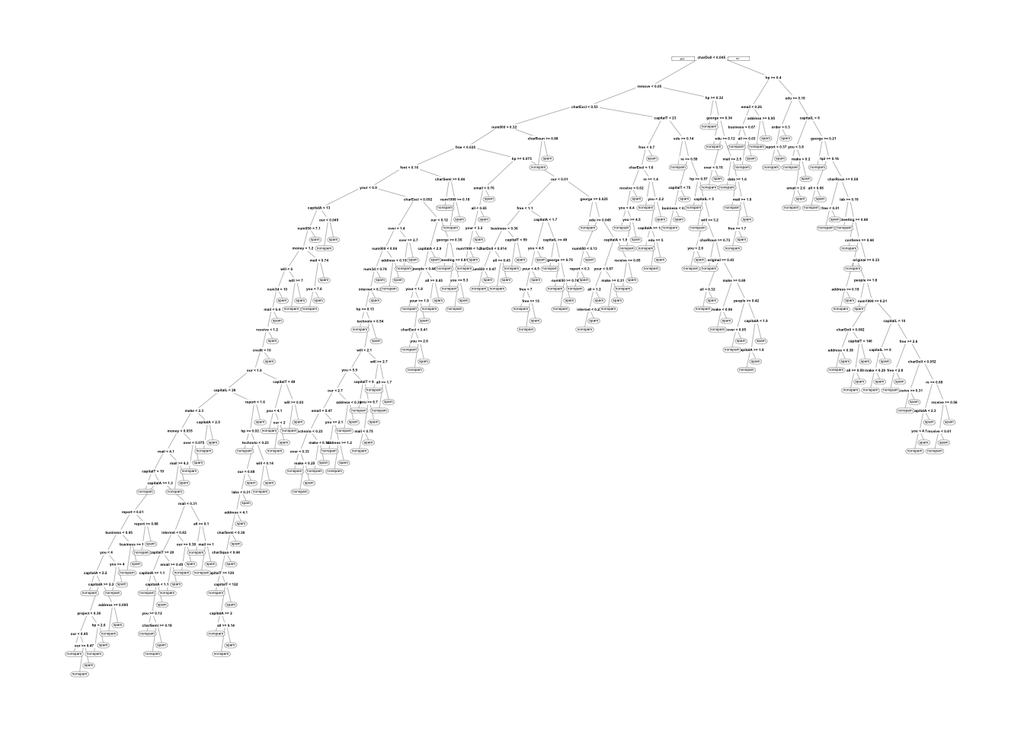

```r
max_rpart_tree<-rpart(type~.,method="class",data=spamtr,
control=rpart.control(minsplit=2,minbucket=1,cp=0))
prp(max_rpart_tree)
```

Table in below shows the change of cross validation error (xerror) and Complexity Parameter (CP) with different number of splits.The minimum cp occured in tree with 214 splits. So the number of leaf node is 215.( # of leaf nodes= # of splits + 1)

```r
set.seed(1000)
print(max_rpart_tree$cptable)
```

```
##              CP nsplit    rel error    xerror       xstd
## 1  0.4783293932      0 1.0000000000 1.0000000 0.02185313
## 2  0.1418439716      1 0.5216706068 0.5571316 0.01851123
## 3  0.0464933018      2 0.3798266351 0.4649330 0.01729934
## 4  0.0386130812      3 0.3333333333 0.3356974 0.01515091
## 5  0.0299448385      4 0.2947202522 0.3136328 0.01471770
## 6  0.0173364854      5 0.2647754137 0.2931442 0.01429423
## 7  0.0102442868      6 0.2474389283 0.2821119 0.01405708
## 8  0.0078802206      7 0.2371946414 0.2765957 0.01393598
## 9  0.0065668505      9 0.2214342002 0.2687155 0.01375994
## 10 0.0055161545     12 0.2017336485 0.2529551 0.01339660
## 11 0.0047281324     13 0.1962174941 0.2427108 0.01315190
## 12 0.0039401103     15 0.1867612293 0.2371946 0.01301720
## 13 0.0035460993     17 0.1788810087 0.2316785 0.01288036
## 14 0.0031520883     19 0.1717888101 0.2308905 0.01286063
## 15 0.0023640662     27 0.1442080378 0.2301024 0.01284086
## 16 0.0021013922     31 0.1347517730 0.2253743 0.01272126
## 17 0.0015760441     34 0.1284475965 0.2253743 0.01272126
## 18 0.0011820331     48 0.1063829787 0.2159180 0.01247695
## 19 0.0010244287     54 0.0992907801 0.2167061 0.01249757
## 20 0.0009193591     64 0.0890464933 0.2143420 0.01243555
## 21 0.0007880221     70 0.0835303388 0.2206462 0.01259997
## 22 0.0005253480    127 0.0362490150 0.2206462 0.01259997
## 23 0.0004728132    131 0.0338849488 0.2277384 0.01278127
## 24 0.0004377900    136 0.0315208826 0.2293144 0.01282104
## 25 0.0003940110    152 0.0244286840 0.2505910 0.01334075
## 26 0.0003581918    188 0.0102442868 0.2505910 0.01334075
## 27 0.0003377237    207 0.0031520883 0.2529551 0.01339660
## 28 0.0000000000    214 0.0007880221 0.2521671 0.01337802
```

# PART C FOR RPART PACKAGE

Predictions in test set with largest tree in rpart:

```r
predict_test_max_rpart<-predict(max_rpart_tree,newdata=spamte,type="class")
table(spamte$type,predict_test_max_rpart)
```

```
##          predict_test_max_rpart
##           nonspam spam
##   nonspam     761   75
##   spam         58  486
```

Error Rate= (58+75)/1380=0.0963768  
False Positive Rate= 75/(761+75)=0.0897129  
False Negative Rate= 58/(486+58)=0.1066176

# PART D FOR RPART PACKAGE

Minimum xerror value in the cptable was found with 64 splits and cp=0.0009193591.

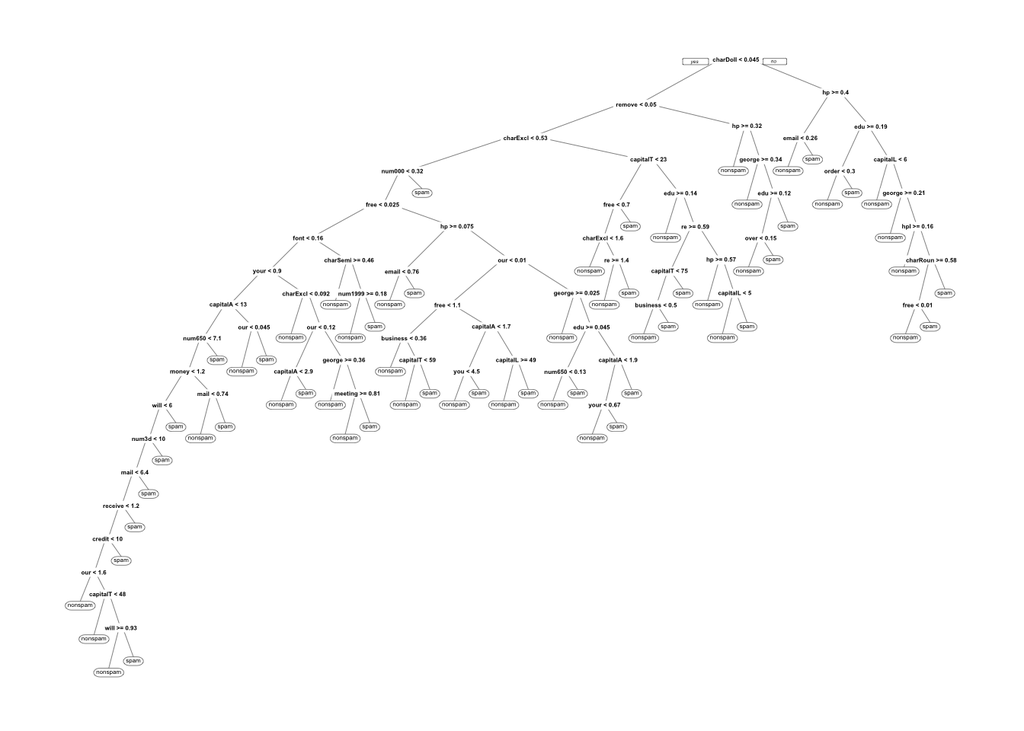

```r
prunedtree_rpart<-prune(tree = max_rpart_tree,cp=0.0009193591)
prp(prunedtree_rpart)
```

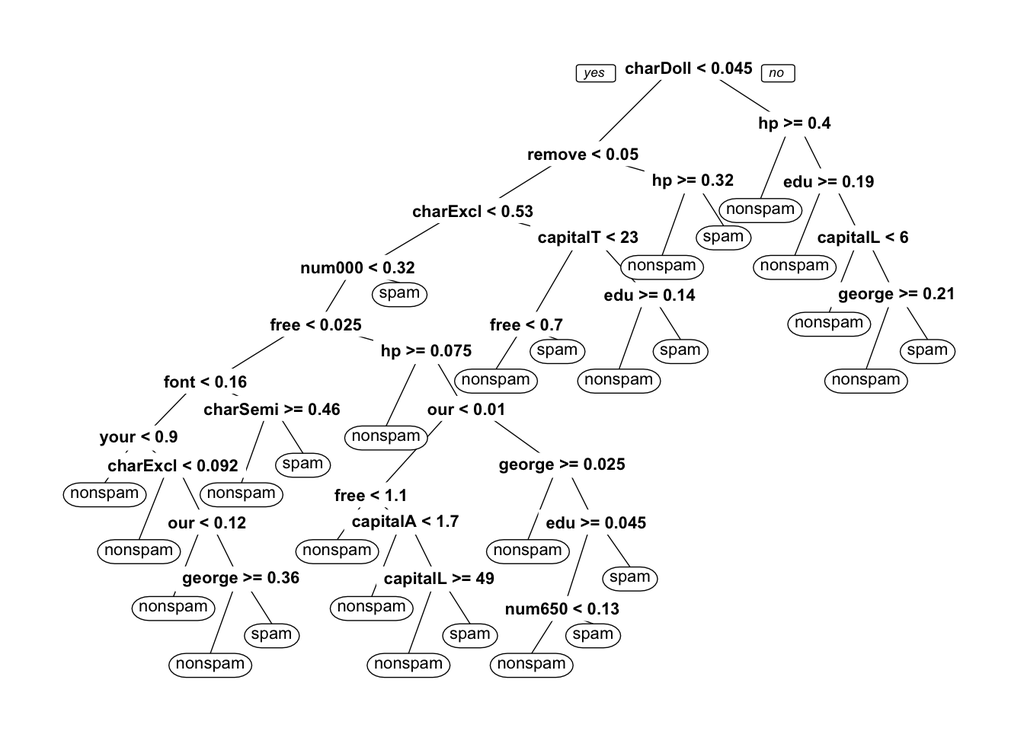

```r
opttree_rpart<-prune(tree = max_rpart_tree,cp=0.0023640662)
prp(opttree_rpart)
```

```r
print(opttree_rpart$cptable)
```

```
##             CP nsplit rel error    xerror       xstd
## 1  0.478329393      0 1.0000000 1.0000000 0.02185313
## 2  0.141843972      1 0.5216706 0.5571316 0.01851123
## 3  0.046493302      2 0.3798266 0.4649330 0.01729934
## 4  0.038613081      3 0.3333333 0.3356974 0.01515091
## 5  0.029944838      4 0.2947203 0.3136328 0.01471770
## 6  0.017336485      5 0.2647754 0.2931442 0.01429423
## 7  0.010244287      6 0.2474389 0.2821119 0.01405708
## 8  0.007880221      7 0.2371946 0.2765957 0.01393598
## 9  0.006566851      9 0.2214342 0.2687155 0.01375994
## 10 0.005516154     12 0.2017336 0.2529551 0.01339660
## 11 0.004728132     13 0.1962175 0.2427108 0.01315190
## 12 0.003940110     15 0.1867612 0.2371946 0.01301720
## 13 0.003546099     17 0.1788810 0.2316785 0.01288036
## 14 0.003152088     19 0.1717888 0.2308905 0.01286063
## 15 0.002364066     27 0.1442080 0.2301024 0.01284086
```

# PART E FOR RPART PACKAGE

Predictions in test set with optimal tree in rpart:

```r
predict_test_opt_rpart<-predict(opttree_rpart,newdata=spamte,type="class")
table(spamte$type,predict_test_opt_rpart)
```

```
##          predict_test_opt_rpart
##           nonspam spam
##   nonspam     787   49
##   spam         62  482
```

Error Rate= (49+62)/1380=0.0804348  
False Positive Rate= 49/(787+49)=0.0586124  
False Negative Rate= 62/(482+62)=0.1139706

**Error rate decreases from 0.0963768 to 0.0804348 after pruning the tree.**

# PART B FOR TREE PACKAGE

Largest possible tree with tree package. It was found by using mindev=0.

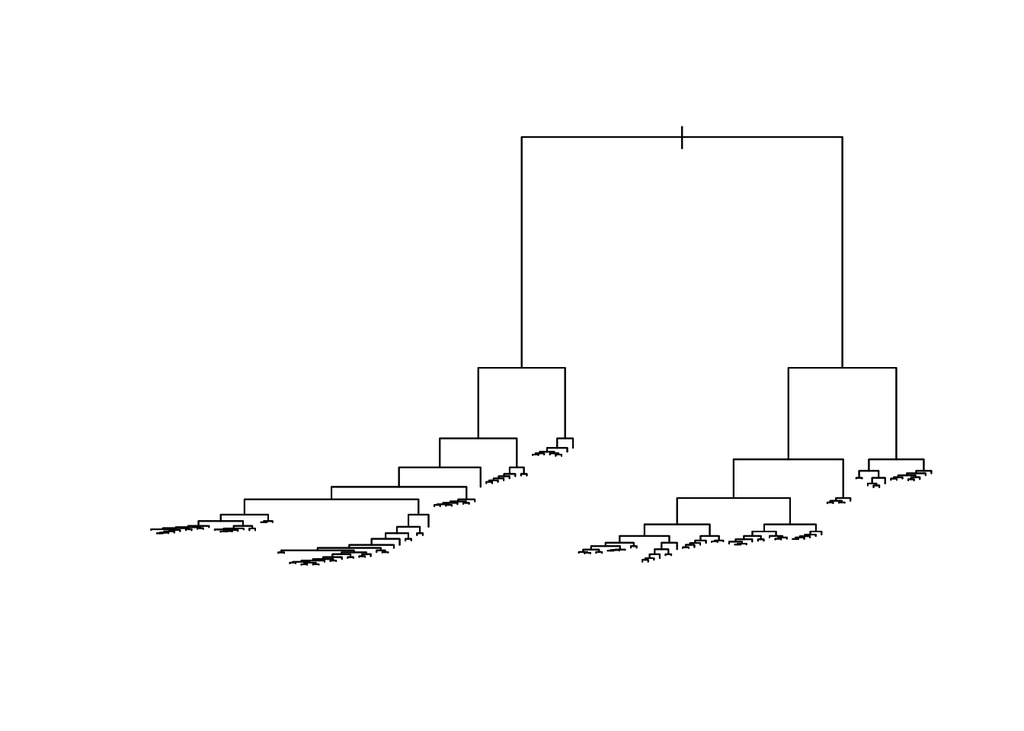

```r
set.seed(1000)
max_treepack_tree<- tree(type~.,data = spamtr,mindev=0)
plot(max_treepack_tree)
```

In summary below, it can be seen that the number of terminal(leaf) nodes is 136 in largest tree achieved by using tree package.

```r
summary(max_treepack_tree)
```

```
##
## Classification tree:
## tree(formula = type ~ ., data = spamtr, mindev = 0)
## Variables actually used in tree construction:
##  [1] "charExclamation"  "remove"           "money"            "george"
##  [5] "hp"               "capitalLong"      "free"             "your"
##  [9] "capitalAve"       "will"             "capitalTotal"     "you"
## [13] "charRoundbracket" "all"              "our"              "num1999"
## [17] "charDollar"       "re"               "technology"       "over"
## [21] "num650"           "edu"              "font"             "pm"
## [25] "receive"          "data"             "internet"         "credit"
## [29] "mail"             "business"         "address"          "people"
## [33] "project"          "order"
## Number of terminal nodes:  136
## Residual mean deviance:  0.1471 = 453.7 / 3085
## Misclassification error rate: 0.03539 = 114 / 3221
```

# PART C FOR TREE PACKAGE

Prediction of test set with largest possible tree found by tree package:

```r
set.seed(1000)
predict_test_max_treepack<-predict(max_treepack_tree,newdata=spamte,type="class")
table(spamte$type,predict_test_max_treepack)
```

```
##          predict_test_max_treepack
##           nonspam spam
##   nonspam     782   54
##   spam         59  485
```

**original rmd file shows 60 and 484 in row 2**

**pdf report shows 59 and 485 in row 2**

Error Rate= (54+59)/1380=0.0818841  
False Positive Rate= 54/(782+54)=0.0645933  
False Negative Rate= 59/(485+59)=0.1084559

# PART D FOR TREE PACKAGE

Finding minimum deviation value which seen in minimum index. This index value (14) is the best size for pruning.

```r
set.seed(1000)
cvtree<- cv.tree(max_treepack_tree,K=10)
min(cvtree$dev)
```

```
## [1] 1820.983
```

```r
best_size<-min(cvtree$size[cvtree$dev==min(cvtree$dev)])
best_size
```

```
## [1] 14
```

Opttree in tree package:

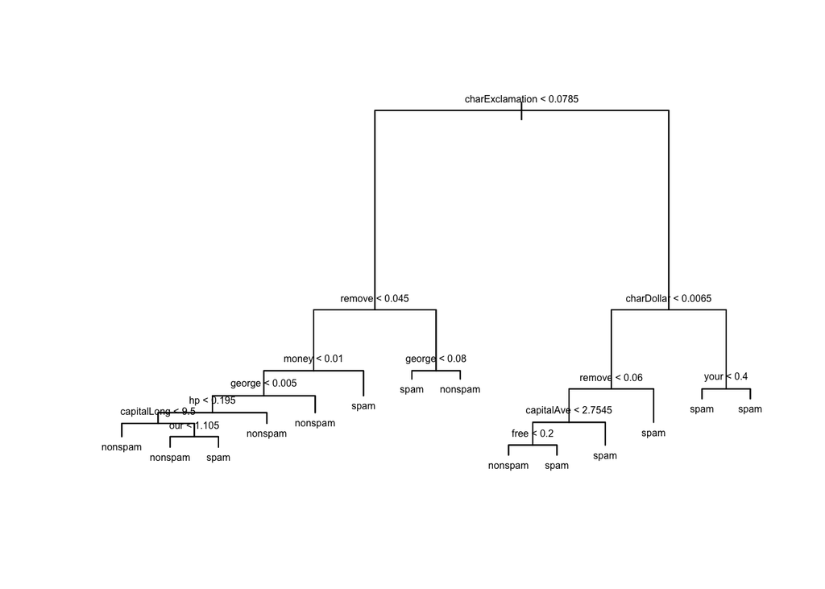

```r
opttree_tree_pack<-prune.tree(max_treepack_tree,best = best_size)
plot(opttree_tree_pack)
text(opttree_tree_pack,cex=0.5)
```

# PART E FOR TREE PACKAGE

Prediction of test set with opttree in tree package:

```r
predict_test_opt_tree<-predict(opttree_tree_pack,newdata=spamte,type="class")
table(spamte$type,predict_test_opt_tree)
```

```
##          predict_test_opt_tree
##           nonspam spam
##   nonspam     775   61
##   spam         65  479
```

Error Rate= (61+65)/1380=0.0913043  
False Positive Rate= 61/(775+61)=0.0729665  
False Negative Rate= 65/(479+65)=0.1194853

# Conclusion

Error rate decreases after pruning the tree created by rpart package. However error rate increases after pruning the tree created by tree package.

**NOTE: There are some differences of xerrors in cptable seen rmarkdown report and cptable seen rscript file.**